# Computer Science 1

**Computer lab 06**

**Course Number:** BTPS1210BA-E  
**Contact Information:** Please contact me through email anytime: abari.kalman@arts.unideb.hu

Author

Kálmán Abari

Published

August 28, 2024

Learning outcomes

Students will learn how to start a statistical analysis.

# Jamovi - Import data, Data conversion

## Problem 1

> In this section, you will learn how to read dataset into jamovi.
1. Go to [SPSS TUTORIALS: HOME](https://libguides.library.kent.edu/SPSS/home) site. Find the ‘Sample Data Files’ section. Download the following datasets:
   - Data - Comma delimited (*.csv): `Sample_Dataset_2014.csv`
   - Data - Tab delimited (*.txt): `Sample_Dataset_2014.txt`
   - Data - Excel format (*.xlsx): `Sample_Dataset_2014.xlsx`
   - Data - SPSS format (*.sav): `Sample_Dataset_2014.sav`

   The content of all 4 datasets is the same, they differ only in the format.
2. Download the `Sample_Dataset_2014_Codebook.pdf` clicking on ’Data definitions (*.pdf)’. Read this codebook. Use the knowledge of the codebook in the following problems.
3. Create 4 OMV files based on the 4 different format datasets (CSV, TXT, XLSX, SAV). Use the `Hamburger menu / Open / This PC / Browse` button to read the files. You will get 4 *jamovi* windows. Name the files as follows:
   - CSV: `dataset_csv.omv`
   - TXT: `dataset_txt.omv`
   - XLSX: `dataset_xlsx.omv`
   - SAV: `dataset_sav.omv`

[figure not shown]

Open a dataset

[figure not shown]

Save a dataset

4. Create a compressed zip file (`datasets.zip`) from the CSV, TXT, XSLX and SAV versions of the OMV dataset files.
5. Send the file `datasets.zip` to the `abari.kalman@arts.unideb.hu`. The subject of this email is `Problem 1`.

## Problem 2

> In this section, you will learn how to review variables.
1. From now on, use file `dataset_xlsx.omv` from Problem 1. Review the variables based on the information in the codebook:
   - add a description to each variable.

   Select the menu `Variable` and fill the column ‘Description’.

[figure not shown]

Add description to the variables

2. Let’s continue the overview of the variables on the file `dataset_xlsx.omv`:
   - set the correct measurement type based on codebook.

   Select the button `Edit` and choose the proper ‘Measure type’. If the variable is nominal, use the ‘Nominal’ item, if it is ordinal, then use ‘Ordinal’, if the variable is an interval or ratio, use the ‘Continues’ item. Use ‘ID’ if the variable identifies a row. Date and time are not handled by jamovi, so they should be set `Nominal` or `Ordinal`.

[figure not shown]

Set the proper measure type

3. Let’s continue the overview of the variables on the file `dataset_xlsx.omv`:
   - if necessary, rename the levels of the categorical variables.

   After reviewing the codebook and the database, it is worth renaming the levels of the following categorical variables:
   - Rank
     - 1 = Freshman
     - 2 = Sophomore
     - 3 = Junior
     - 4 = Senior
   - Gender
     - 0 = Male
     - 1 = Female
   - Athlete
     - 0 = Non-athlete
     - 1 = Athlete
   - Smoker
     - 0 = Nonsmoker
     - 1 = Past smoker
     - 2 = Current smoker
   - LiveOnCampus
     - 0 = Off-campus
     - 1 = On-campus
   - HowCommute
     - 1 = Walk
     - 2 = Bike
     - 3 = Car
     - 4 = Public transit
     - 5 = Other

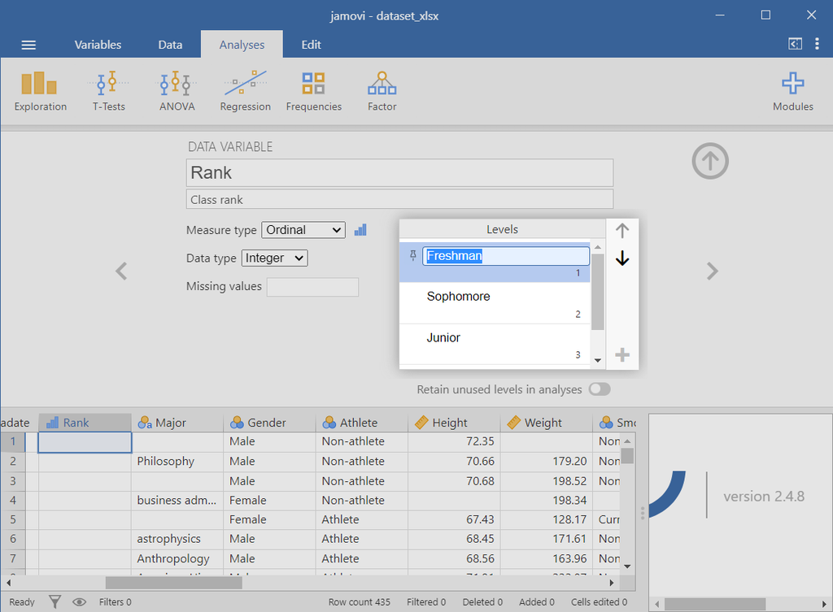

Rename the levels of variable ‘Rank’

Note that all the level names in the codebook are also among the level names of the categorical variable. Even when such a level name does not occur in the current database. Such is the `HowCommute` variable in our case, when we had to enter the value ‘5=Others’. In such a case, do not forget to turn on the `Retain unused levels in analyses` switch.

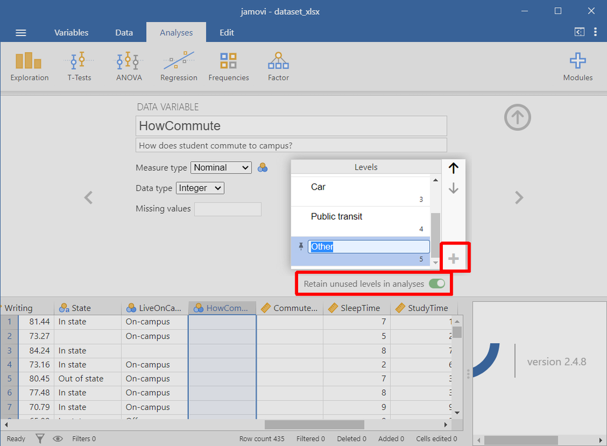

Add new levels to factor ‘HowCommute’

4. Send the file `dataset_xlsx.omv` to the `abari.kalman@arts.unideb.hu`. The subject of this email is `Problem 2`.

## Problem 3

> In this section, you will practice *jamovi* data conversion.
1. Download the `star` ‘Student Teacher Achievement Ratio (STAR) project data’ from [this site](https://vincentarelbundock.github.io/Rdatasets/datasets.html).
2. Open the dataset in *jamovi* and save as `star.omv`.
3. Review the dataset variables based on `star`’s DOC link:
   - have meaningful variable names
   - have a description
   - all variables must be in the correct measurement type
   - categorical variables should have all levels (used and unused)
   - all level names should be meaningful
   - in the case of ordinal variables, the levels should be in the correct order.
4. Send your `star.omv` to the `abari.kalman@arts.unideb.hu`. The subject of this email is `Problem 3`. **The better the solution, the more badges you get (from three to zero).**

## Problem 4

> In this section you will learn how to extend *jamovi* with new capabilities.
1. Jamovi’s knowledge can be expanded with modules. Install the following modules and take before and after pictures to show how the modules will look in jamovi:
   - moretests
   - ztestvis
   - lsj-data
   - r-datasets

   Each installed module should therefore have 2 images.

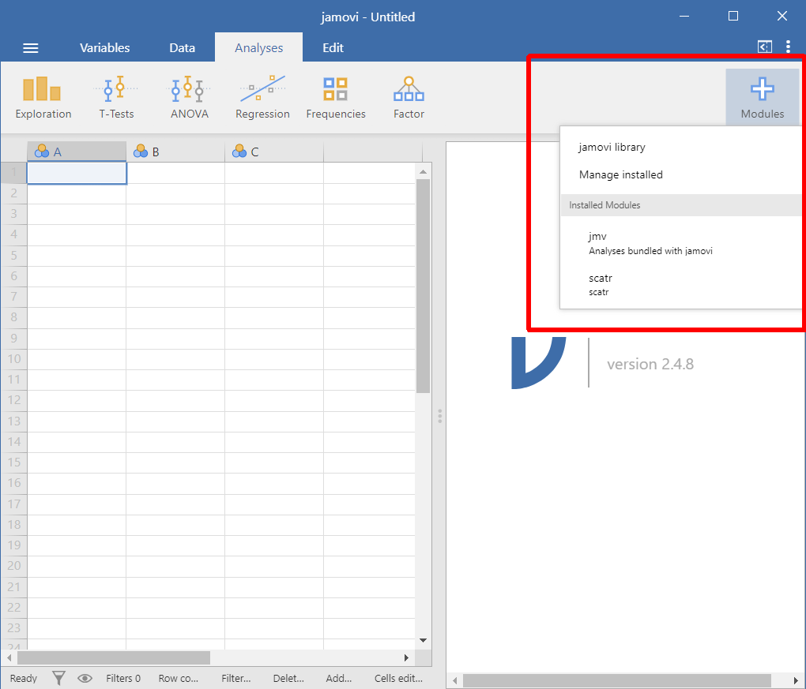

Add a new model

2. Summarize the installation of the 4 modules above and the total of 8 screenshots in a new RStudio project, a Quarto document. Create an HTML file named `modules.html`.
3. Send your `modules.html` to the `abari.kalman@arts.unideb.hu`. The subject of this email is `Problem 4`. **The better the solution, the more badges you get (from four to zero).**